# Homework 4 Solutions

Biostatistics 735 — Machine Learning in Public Health

Author

Alexander McLain

Published

October 7, 2026

```r
# Core
library(tidyverse)
library(tidymodels)
library(kableExtra)
library(janitor)

# Specific models & utilities
library(caret)        # naive Bayes / random forest with tuned mtry
library(MASS)         # birthwt
library(rpart)        # CART
library(rpart.plot)   # tree plots
library(ranger)       # fast RF backend
library(glmnet)       # lasso / ridge
library(pdp)          # partial dependence
library(NHANES)       # Question 3
library(modeldata)    # ad_data, Question 4
library(torch)        # Question 4
library(luz)

# MASS masks dplyr::select; make sure select() means dplyr's
select <- dplyr::select

# Small helper: nice tables
kbl2 <- function(x, ...) kable(x, align = "lrrrrrr", ...) %>% kable_styling(full_width = FALSE)
```

A helper to compute the metrics we’ve discussed (AUC is threshold-free; the others use a threshold, default 0.5). Note that I’ve added a warning if the AUC is less than $0.5$.

```r
eval_metrics <- function(truth, prob_pos, level_vals = NA, thr = 0.5) {
  if(is.na(level_vals)){
    if(!is.factor(truth)){
      if(identical(sort(unique(truth)), c(0,1))){
        level_vals <- c("0", "1")
      }else{
        stop("Truth must be a factor, binary 0/1, or the levels need to be given")
      }
    }else{
      level_vals = levels(truth)
    }
  }
  if(!is.factor(truth)){truth <- factor(truth, levels = level_vals)}
  cls   <- factor(ifelse(prob_pos <= thr, level_vals[1],level_vals[2]), levels = level_vals)
  res <- tibble(
    AUC  = roc_auc_vec(truth, prob_pos, event_level = "second"),
    Sens = sens_vec(truth, cls,        event_level = "second"),
    Spec = spec_vec(truth, cls,        event_level = "second"),
    PPV  = ppv_vec (truth, cls,        event_level = "second"),
    NPV  = npv_vec (truth, cls,        event_level = "second"),
    Acc  = accuracy_vec(truth, cls)
  )
  if(res$AUC < 0.5){warning(paste("The AUC is less than 0.5. Check the coding consistency. \n
                                  High probability currently means the subject is more likely", level_vals[1]))}
  return(res)
}
```

# Question 1: Naive Bayes on dataset from UCI (Cleveland version)

## 1(a) Explore the dataset

```r
# --- Read the dataset from UCI (Cleveland version) ---
url <- "https://archive.ics.uci.edu/ml/machine-learning-databases/heart-disease/processed.cleveland.data"

heart_raw <- read.csv(url, header = FALSE, na.strings = "?")

# --- Assign variable names based on UCI documentation ---
colnames(heart_raw) <- c(
  "age",        # age in years
  "sex",        # sex (1 = male; 0 = female)
  "cp",         # chest pain type (1–4)
  "trestbps",   # resting blood pressure (mm Hg)
  "chol",       # serum cholesterol (mg/dl)
  "fbs",        # fasting blood sugar > 120 mg/dl (1 = true; 0 = false)
  "restecg",    # resting electrocardiographic results (0–2)
  "thalach",    # max heart rate achieved
  "exang",      # exercise induced angina (1 = yes; 0 = no)
  "oldpeak",    # ST depression induced by exercise relative to rest
  "slope",      # slope of peak exercise ST segment (1–3)
  "ca",         # number of major vessels (0–3) colored by fluoroscopy
  "thal",       # 3 = normal; 6 = fixed defect; 7 = reversible defect
  "target"      # 0 = no disease; 1–4 = presence of heart disease
)


# --- Convert columns to appropriate types ---
heart_clean <- heart_raw %>%
  mutate(
    sex      = factor(sex, levels = c(0, 1), labels = c("Female", "Male")),
    cp       = factor(cp, levels = 1:4, labels = c("Typical", "Atypical", "Non-anginal", "Asymptomatic")),
    fbs      = factor(fbs, levels = c(0, 1), labels = c("False", "True")),
    restecg  = factor(restecg, levels = 0:2, labels = c("Normal", "ST-T abnormality", "LVH")),
    exang    = factor(exang, levels = c(0, 1), labels = c("No", "Yes")),
    slope    = factor(slope, levels = 1:3, labels = c("Upsloping", "Flat", "Downsloping")),
    ca       = as.numeric(ca),
    thal     = factor(thal, levels = c(3, 6, 7), labels = c("Normal", "Fixed", "Reversible")),
    target   = factor(ifelse(target == 0, "NoDisease", "Disease"))
  )

# --- Handle missing values ---
# Count missing (not much)
colSums(is.na(heart_clean))
```

```
     age      sex       cp trestbps     chol      fbs  restecg  thalach
       0        0        0        0        0        0        0        0
   exang  oldpeak    slope       ca     thal   target
       0        0        0        4        2        0
```

```r
# Drop rows with missing values (most analyses do)
heart_final <- heart_clean %>% drop_na()
```

## 1(b) Train/Test Split

```r
set.seed(42)
split <- initial_split(heart_final, prop = 0.7)
train <- training(split)
test  <- testing(split)

nrow(train); nrow(test)
```

```
[1] 207
```

```
[1] 90
```

## 1(c) Fit Naive Bayes (Caret)

```r
train_control <- trainControl(
  method = "cv",
  number = 10,
  classProbs = TRUE,
  summaryFunction = twoClassSummary)

tune_grid <- expand.grid(
  laplace = c(0, 0.5, 1),
  usekernel = c(TRUE, FALSE),
  adjust = c(0.5, 1, 2)
)

set.seed(123)
fit_nb <- train(
  target ~ .,
  data = train,
  method = "naive_bayes",
  metric = "ROC",
  trControl = train_control,
  tuneGrid = tune_grid
)

fit_nb$bestTune
```

```
  laplace usekernel adjust
6       0      TRUE      2
```

## 1(d) Evaluate on Test Set

```r
nb_pred_prob <- predict(fit_nb, newdata = test, type = "prob")[, "NoDisease"]
nb_pred_cls  <- predict(fit_nb, newdata = test)

nb_results <- eval_metrics(test$target, nb_pred_prob, thr = 0.5)
nb_results %>% kbl2(digits = 3)
```

| AUC | Sens | Spec | PPV | NPV | Acc |
| --- | --- | --- | --- | --- | --- |
| 0.897 | 0.695 | 0.839 | 0.891 | 0.591 | 0.744 |

## 1(e) Re-fit with Binned Variables

```r
# Example: bin Age and Cholesterol
heart_binned <- heart_final %>%
  mutate(
    AgeBin  = cut(age, breaks = c(0, 45, 55, 65, Inf), right = FALSE),
    CholBin = cut(chol, breaks = quantile(chol, probs = seq(0, 1, 0.25), na.rm = TRUE), include.lowest = TRUE)
  ) %>%
  dplyr::select(-age, -chol)

split_h2 <- initial_split(heart_binned, prop = 0.7)
h2_tr <- training(split_h2)
h2_te <- testing(split_h2)

nb_fit2 <- caret::train(
  target ~ .,
  data = h2_tr,
  method = "naive_bayes",
  metric = "ROC",
  trControl = train_control,
  tuneGrid = tune_grid
)

nb2_prob <- predict(nb_fit2, newdata = h2_te, type = "prob")[, "NoDisease"]
nb2_cls  <- predict(nb_fit2, newdata = h2_te)

nb_results2 <- eval_metrics(h2_te$target, nb2_prob, thr = 0.5)

### Compare the results

nb_results %>%
  mutate(Type = "Original", .before = AUC) %>%
  bind_rows(
    nb_results2 %>% mutate(Type = "Binned", .before = AUC)
  ) %>%
  kbl2(digits = 3)
```

| Type | AUC | Sens | Spec | PPV | NPV | Acc |
| --- | --- | --- | --- | --- | --- | --- |
| Original | 0.897 | 0.695 | 0.839 | 0.891 | 0.591 | 0.744 |
| Binned | 0.925 | 0.727 | 0.891 | 0.865 | 0.774 | 0.811 |

**Interpretation:** Compare AUC/accuracy/sens/spec between raw vs. binned features; Naive Bayes can benefit when independence assumptions are closer to true after discretization.

## 1(f) When is Naive Bayes advantageous?

- Works well with mixed data and small samples, robust with many predictors.
- Fast baseline; often competitive when conditional independence is approximately satisfied.
- In public health, good for quick triage models / risk screening where interpretability and speed matter.

# Question 2: CART Regression Tree — `MASS::birthwt`

## 2(a) Describe Data

```r
data(birthwt, package = "MASS")
bw <- birthwt %>% dplyr::select(-low) %>% as_tibble()
glimpse(bw)
```

```
Rows: 189
Columns: 9
$ age   <int> 19, 33, 20, 21, 18, 21, 22, 17, 29, 26, 19, 19, 22, 30, 18, 18, …
$ lwt   <int> 182, 155, 105, 108, 107, 124, 118, 103, 123, 113, 95, 150, 95, 1…
$ race  <int> 2, 3, 1, 1, 1, 3, 1, 3, 1, 1, 3, 3, 3, 3, 1, 1, 2, 1, 3, 1, 3, 1…
$ smoke <int> 0, 0, 1, 1, 1, 0, 0, 0, 1, 1, 0, 0, 0, 0, 1, 1, 0, 1, 0, 1, 0, 0…
$ ptl   <int> 0, 0, 0, 0, 0, 0, 0, 0, 0, 0, 0, 0, 0, 1, 0, 0, 0, 0, 0, 0, 0, 0…
$ ht    <int> 0, 0, 0, 0, 0, 0, 0, 0, 0, 0, 0, 0, 1, 0, 0, 0, 0, 0, 0, 0, 0, 0…
$ ui    <int> 1, 0, 0, 1, 1, 0, 0, 0, 0, 0, 0, 0, 0, 1, 0, 0, 0, 0, 1, 0, 0, 1…
$ ftv   <int> 0, 3, 1, 2, 0, 0, 1, 1, 1, 0, 0, 1, 0, 2, 0, 0, 0, 3, 0, 1, 2, 3…
$ bwt   <int> 2523, 2551, 2557, 2594, 2600, 2622, 2637, 2637, 2663, 2665, 2722…
```

```r
summary(bw$bwt)
```

```
   Min. 1st Qu.  Median    Mean 3rd Qu.    Max.
    709    2414    2977    2945    3487    4990
```

Outcome: `bwt` (birth weight, grams). Predictors include maternal age, weight, race, smoking status, hypertension history, etc.

## 2(b) Fit CART Regression Tree

```r
set.seed(2)
tree_fit <- rpart(bwt ~ ., data = bw, method = "anova",
                  control = rpart.control(cp = 0.001, minsplit = 10))
printcp(tree_fit)
```

```
Regression tree:
rpart(formula = bwt ~ ., data = bw, method = "anova", control = rpart.control(cp = 0.001,
    minsplit = 10))

Variables actually used in tree construction:
[1] age   ht    lwt   race  smoke ui

Root node error: 99969656/189 = 528940

n= 189

          CP nsplit rel error  xerror    xstd
1  0.0844485      0   1.00000 1.01425 0.10179
2  0.0818680      1   0.91555 1.03317 0.10524
3  0.0434671      2   0.83368 0.96519 0.11559
4  0.0293049      4   0.74675 0.97306 0.11238
5  0.0240662      6   0.68814 0.99425 0.11159
6  0.0238337      7   0.66407 1.01238 0.11368
7  0.0178182      9   0.61641 1.02294 0.11379
8  0.0129702     10   0.59859 1.12247 0.12673
9  0.0129541     11   0.58562 1.14487 0.13116
10 0.0127575     12   0.57266 1.14343 0.13122
11 0.0120921     13   0.55991 1.15018 0.13186
12 0.0111578     14   0.54781 1.17027 0.13302
13 0.0099946     15   0.53666 1.21440 0.14026
14 0.0099247     16   0.52666 1.22104 0.14022
15 0.0093123     17   0.51674 1.22431 0.14014
16 0.0086887     18   0.50742 1.23728 0.14050
17 0.0082723     19   0.49874 1.29004 0.15485
18 0.0078314     21   0.48219 1.31391 0.15539
19 0.0072483     25   0.45087 1.33272 0.15547
20 0.0067943     29   0.41873 1.33799 0.15546
21 0.0049514     31   0.40514 1.35509 0.15541
22 0.0048466     33   0.39524 1.34795 0.15509
23 0.0036095     34   0.39039 1.34087 0.15493
24 0.0010000     35   0.38679 1.35546 0.15489
```

## 2(c) Cross-Validation for cp

```r
best_cp <- tree_fit$cptable[which.min(tree_fit$cptable[,"xerror"]), "CP"]
best_cp
```

```
[1] 0.04346711
```

```r
tree_pruned <- prune(tree_fit, cp = best_cp)
```

## 2(d) Plot and Interpret Top Splits

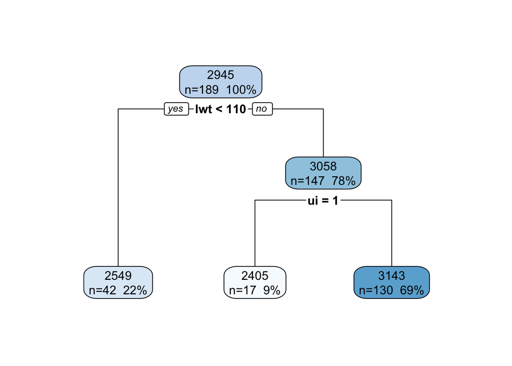

```r
rpart.plot(tree_pruned, extra = 101)
```

> **Interpretation (partial):** The first split is on `lwt`, separating mothers with `lwt < 110` vs `lwt>= 110`. In context, this suggests mother’s with lower weight in pounds at last menstrual period have babies that weigh less. The second split further differentiates for women who had `lwt>= 110`, for those that had presence of uterine irritability, their babies weighed less.

## 2(e) Compare RMSE to Linear Regression

```r
set.seed(2)
split_bw <- initial_split(bw, prop = 0.8, strata = NULL)
bw_tr <- training(split_bw)
bw_te <- testing(split_bw)

# Fit/prune on training data using best_cp from full fit (simple approach)
tree_pruned_te <- predict(prune(rpart(bwt ~ ., data = bw_tr, method="anova",
                                      control = rpart.control(cp = best_cp)), cp = best_cp), newdata = bw_te)

lm_fit <- lm(bwt ~ ., data = bw_tr)
lm_pred <- predict(lm_fit, newdata = bw_te)

rmse_tree <- yardstick::rmse_vec(bw_te$bwt, tree_pruned_te)
rmse_lm   <- yardstick::rmse_vec(bw_te$bwt, lm_pred)
c(RMSE_tree = rmse_tree, RMSE_lm = rmse_lm)
```

```
RMSE_tree   RMSE_lm
 719.3907  638.0250
```

## 2(f) Overfitting (Optional)

Deep trees can overfit noise (low training error, poor generalization). Using CP pruning via CV reduces leads to better generalization and lower test error.

# Question 3: Random Forest and Penalized Regression — NHANES

We use the NHANES data from the dimension reduction example and predict body mass index (`bmi`), a continuous outcome.

## 3(a) Clean, Split, and Preprocess

We apply the cleaning code from the assignment. We then drop variables that would make the problem trivial or are redundant copies of other columns: `weight` and `height` (BMI is a deterministic function of the two), `bmi_who` (a categorized version of the outcome), `id`, `age_decade` (a binned `age`), `hh_income` (a categorized `hh_income_mid`), and the individual blood-pressure readings (`bp_sys1`-`bp_dia3`), which are summarized by `bp_sys_ave` and `bp_dia_ave`.

```r
nhanes <- NHANES |>
  clean_names() |>
  distinct(id, .keep_all = TRUE) |>
  select(where(~ mean(is.na(.x)) <= 0.20)) |>
  drop_na() |>
  select(-id, -weight, -height, -bmi_who, -age_decade, -hh_income,
         -matches("^bp_(sys|dia)[123]$"))

dim(nhanes)
```

```
[1] 3727   18
```

```r
names(nhanes)
```

```
 [1] "survey_yr"     "gender"        "age"           "race1"
 [5] "hh_income_mid" "poverty"       "home_rooms"    "home_own"
 [9] "bmi"           "pulse"         "bp_sys_ave"    "bp_dia_ave"
[13] "direct_chol"   "tot_chol"      "urine_vol1"    "urine_flow1"
[17] "diabetes"      "phys_active"
```

```r
set.seed(3)
split_nh <- initial_split(nhanes, prop = 0.7)
nh_tr <- training(split_nh)
nh_te <- testing(split_nh)

# no missing values remain, so the recipe only needs dummy coding and normalizing
rec_nh <- recipe(bmi ~ ., data = nh_tr) |>
  step_dummy(all_nominal_predictors()) |>
  step_zv(all_predictors()) |>
  step_normalize(all_numeric_predictors())

prep_nh <- prep(rec_nh)
nh_tr_baked <- bake(prep_nh, new_data = nh_tr)
nh_te_baked <- bake(prep_nh, new_data = nh_te)
c(train = nrow(nh_tr), test = nrow(nh_te), predictors = ncol(nh_tr_baked) - 1)
```

```
     train       test predictors
      2608       1119         21
```

## 3(b) Fit a Random Forest (fixed `ntree`/`mtry`)

```r
rf_spec <- rand_forest(mtry = 5, trees = 500, min_n = 5) |>
  set_engine("ranger", importance = "permutation") |>
  set_mode("regression")

wf_rf <- workflow() |> add_model(rf_spec) |> add_recipe(rec_nh)
fit_rf <- fit(wf_rf, data = nh_tr)
fit_rf
```

```
══ Workflow [trained] ══════════════════════════════════════════════════════════
Preprocessor: Recipe
Model: rand_forest()

── Preprocessor ────────────────────────────────────────────────────────────────
3 Recipe Steps

• step_dummy()
• step_zv()
• step_normalize()

── Model ───────────────────────────────────────────────────────────────────────
Ranger result

Call:
 ranger::ranger(x = maybe_data_frame(x), y = y, mtry = min_cols(~5,      x), num.trees = ~500, min.node.size = min_rows(~5, x), importance = ~"permutation",      num.threads = 1, verbose = FALSE, seed = sample.int(10^5,          1))

Type:                             Regression
Number of trees:                  500
Sample size:                      2608
Number of independent variables:  21
Mtry:                             5
Target node size:                 5
Variable importance mode:         permutation
Splitrule:                        variance
OOB prediction error (MSE):       37.59651
R squared (OOB):                  0.2340795
```

## 3(c) Tune `mtry` via Cross-Validation

```r
set.seed(3)
folds_nh <- vfold_cv(nh_tr, v = 5)
n_pred <- ncol(nh_tr_baked) - 1
grid_rf <- tibble(mtry = unique(round(seq(2, n_pred, length.out = 8))))

rf_tune_spec <- rand_forest(mtry = tune(), trees = 500, min_n = 5) |>
  set_engine("ranger", importance = "permutation") |>
  set_mode("regression")

rf_tuned <- tune_grid(
  wf_rf |> update_model(rf_tune_spec),
  resamples = folds_nh,
  grid = grid_rf,
  metrics = metric_set(rmse, rsq)
)

collect_metrics(rf_tuned) |>
  filter(.metric == "rmse") |>
  select(mtry, mean, std_err) |>
  kbl2(digits = 3, caption = "5-fold CV RMSE by mtry")
```

5-fold CV RMSE by mtry

| mtry | mean | std_err |
| --- | --- | --- |
| 2 | 6.223 | 0.018 |
| 5 | 6.164 | 0.019 |
| 7 | 6.167 | 0.020 |
| 10 | 6.174 | 0.025 |
| 13 | 6.198 | 0.023 |
| 16 | 6.204 | 0.036 |
| 18 | 6.223 | 0.031 |
| 21 | 6.233 | 0.034 |

```r
best_mtry <- select_best(rf_tuned, metric = "rmse")
best_mtry
```

```
# A tibble: 1 × 2
   mtry .config
  <dbl> <chr>
1     5 pre0_mod2_post0
```

```r
rf_final <- finalize_workflow(wf_rf |> update_model(rf_tune_spec), best_mtry)
fit_rf_final <- fit(rf_final, data = nh_tr)
```

## 3(d) Variable Importance

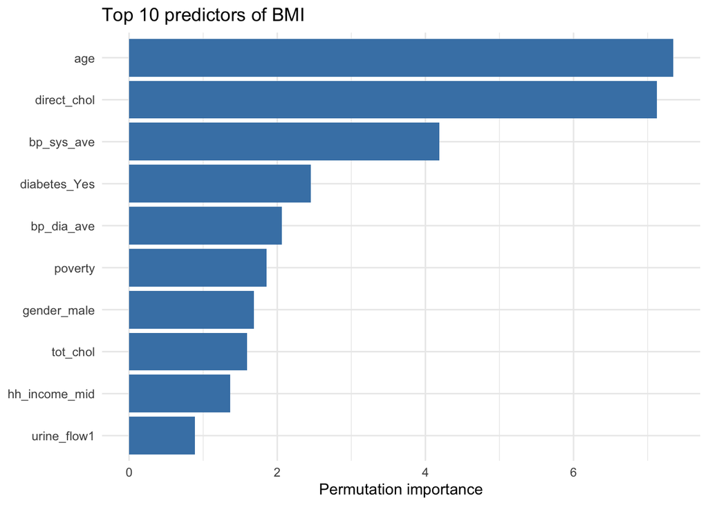

```r
rf_obj <- extract_fit_parsnip(fit_rf_final)$fit

imp <- tibble(variable = names(rf_obj$variable.importance),
              importance = rf_obj$variable.importance) |>
  arrange(desc(importance))

imp |>
  slice_head(n = 10) |>
  mutate(variable = fct_reorder(variable, importance)) |>
  ggplot(aes(importance, variable)) +
  geom_col(fill = "steelblue") +
  labs(x = "Permutation importance", y = NULL, title = "Top 10 predictors of BMI") +
  theme_minimal()
```

> **Interpretation:** The top three predictors are `age`, `direct_chol` (HDL cholesterol), and `bp_sys_ave` (systolic blood pressure), with `age` and `direct_chol` close to tied and well ahead of the rest. Permutation importance measures how much the out-of-bag prediction error increases when a predictor is shuffled, so these are the variables whose information the forest relies on most. The importance does not give the direction of the association, and it can be shared among correlated predictors (blood pressure, cholesterol, and diabetes are all related to age and adiposity). Note that these are *predictive* associations, not causal effects.

## 3(e) Partial Dependence Plot

```r
top_var <- imp$variable[1]
top_var
```

```
[1] "age"
```

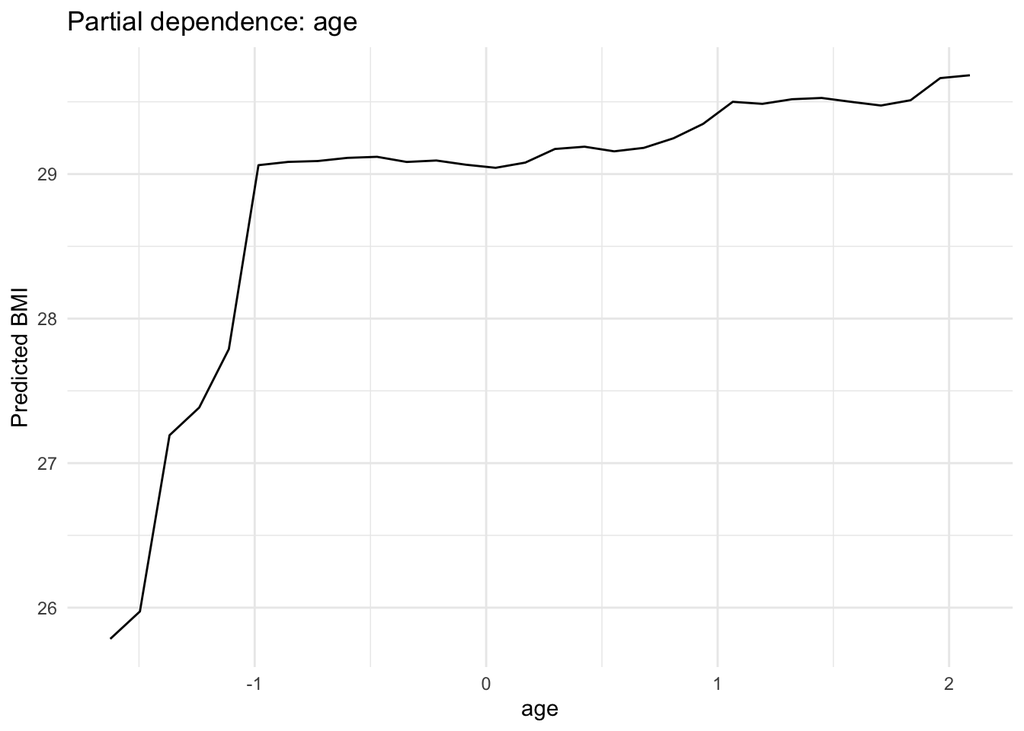

```r
pdp::partial(
  object          = rf_obj,
  pred.var        = top_var,
  train           = nh_tr_baked,
  grid.resolution = 30
) |>
  autoplot() +
  labs(y = "Predicted BMI", title = paste("Partial dependence:", top_var)) +
  theme_minimal()
```

> **Interpretation:** Predicted BMI rises steeply from the youngest participants (about 12 years old) to around age 20, from roughly 26 to 29 kg/m$^2$, and then levels off, increasing only slightly (about 29 to 30 kg/m$^2$) through the 70s. The partial dependence plot averages over the other predictors, so this is the average predicted BMI at each age, not an individual’s trajectory. The sharp rise followed by a plateau is a nonlinear shape a linear model would miss. Because the sample includes adolescents, a good part of the “age effect” reflects growth.

## 3(f) Penalized Regression

We fit a lasso with `cv.glmnet()` (5-fold CV on the training data) on the preprocessed predictors, and use the penalty that minimizes the cross-validated MSE (`lambda.min`).

```r
x_tr <- as.matrix(select(nh_tr_baked, -bmi))
x_te <- as.matrix(select(nh_te_baked, -bmi))

set.seed(3)
cv_lasso <- cv.glmnet(x_tr, nh_tr_baked$bmi, alpha = 1, nfolds = 5)
cv_lasso
```

```
Call:  cv.glmnet(x = x_tr, y = nh_tr_baked$bmi, nfolds = 5, alpha = 1)

Measure: Mean-Squared Error

    Lambda Index Measure     SE Nonzero
min 0.0219    49   38.78 0.5860      20
1se 0.1696    27   39.30 0.4819      14
```

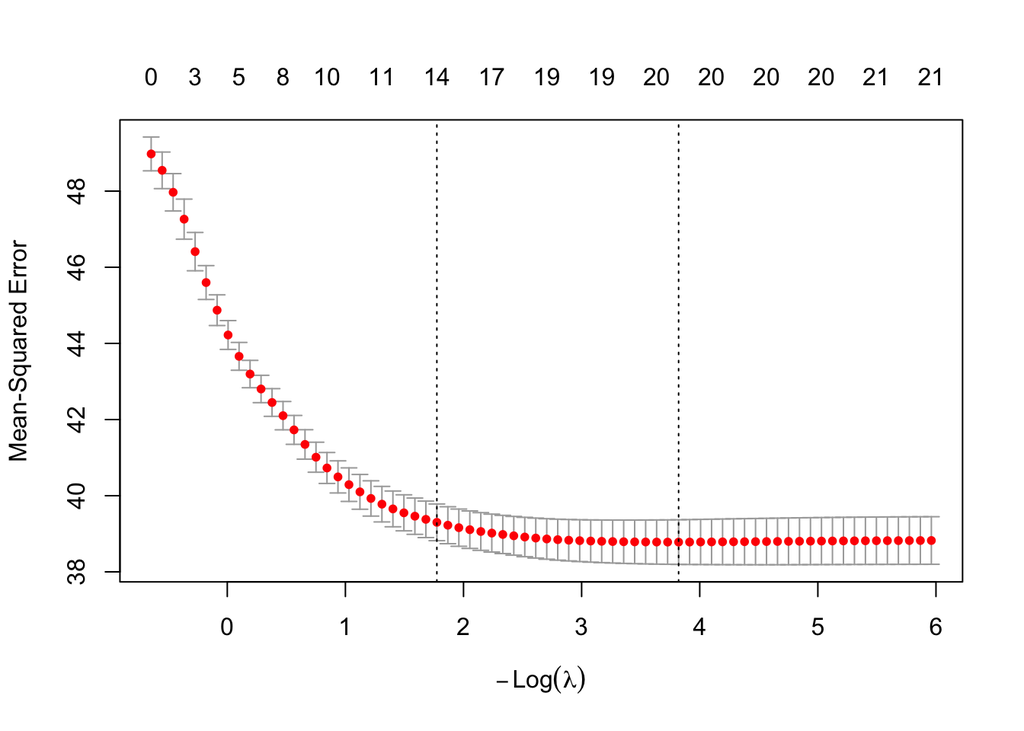

```r
plot(cv_lasso)
```

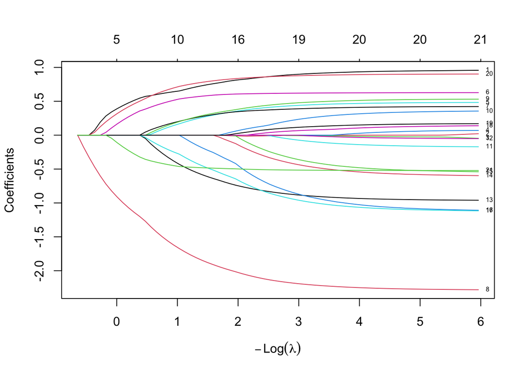

```r
plot(cv_lasso$glmnet.fit, xvar = "lambda", label = TRUE)
abline(v = log(cv_lasso$lambda.min), lty = 2)
```

The first plot shows the cross-validated MSE across the penalty path (the dotted lines mark `lambda.min` and `lambda.1se`), and the second shows the coefficient paths shrinking to zero as the penalty grows.

```r
coef_lasso <- coef(cv_lasso, s = "lambda.min")
tibble(term = rownames(coef_lasso), estimate = as.numeric(coef_lasso)) |>
  filter(estimate != 0, term != "(Intercept)") |>
  arrange(desc(abs(estimate))) |>
  slice_head(n = 10) |>
  kbl2(digits = 3, caption = "Largest lasso coefficients (standardized predictors)")
```

Largest lasso coefficients (standardized predictors)

| term | estimate |
| --- | --- |
| direct_chol | -2.243 |
| race1_Other | -1.053 |
| race1_White | -1.008 |
| age | 0.930 |
| gender_male | -0.928 |
| diabetes_Yes | 0.892 |
| bp_sys_ave | 0.624 |
| race1_Hispanic | -0.530 |
| phys_active_Yes | -0.519 |
| tot_chol | 0.509 |